## Life and death aboard the Titanic

### An exploration into machine learning using the Kaggle Titanic dataset

### By Greg Giles

# Introduction

The sinking of the RMS Titanic is one of the most infamous shipwrecks in history. On April 15, 1912, during her maiden voyage, the Titanic sank after colliding with an iceberg, killing 1502 out of 2224 passengers and crew. This sensational tragedy shocked the international community and led to better safety regulations for ships.

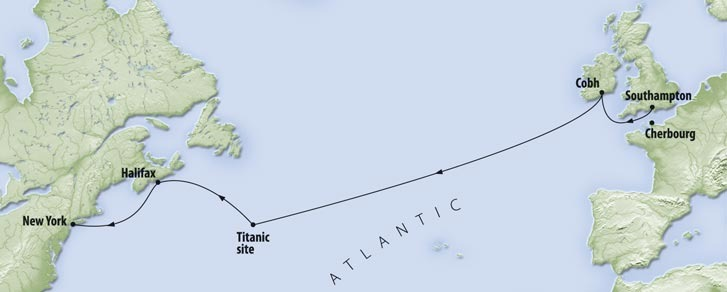

```python
Embed = Image('Titanic-Route.jpg', embed = True)
Embed
```

In this challenge, we are asked to complete the analysis of what sorts of people were likely to survive. This particular presentation focuses on using the tools of machine learning to predict which passengers survived the tragedy.

# Exploring the Data

There are two datasets we will need to address, one for training our model and a second for testing purposes. For the initial data preparation and data cleaning, the datasets will be merged.

Now we can begin the exploration! Let's start by taking a look at the variables we have available.

```python
full[full.Name.str.contains('Hosono')]
```

|  | Age | Cabin | Embarked | Fare | Name | Parch | PassengerId | Pclass | Sex | SibSp | Survived | Ticket | df |
| --- | --- | --- | --- | --- | --- | --- | --- | --- | --- | --- | --- | --- | --- |
| 288 | 42.0 | NaN | S | 13.0 | Hosono, Mr. Masabumi | 0 | 289 | 2nd Class | male | 0 | 1.0 | 237798 | Train |

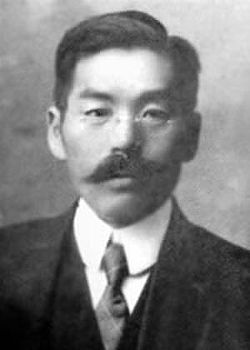

```python
Hosono = Image('Masabumi_Hosono.jpeg')
Hosono
```

## Data Types

```python
full.dtypes
```

```
Age             float64
Cabin            object
Embarked         object
Fare            float64
Name             object
Parch             int64
PassengerId       int64
Pclass         category
Sex              object
SibSp             int64
Survived        float64
Ticket           object
df               object
dtype: object
```

Scikit learn, the package we will be using to build our classification model, does not accept string values as input, so for use in the model, we will need to have integer representation of our categorical variables. With simple dichotomous variables e.g. gender, we can use binarization, but for nominal multiclass variables we do not want to imply an order, so a method like one-hot encoding would be useful.

# Dealing with missing values

*Number of missing values for each variable:*

```python
cols = [col for col in full.columns.values if col not in ['Survived']]
full[cols].isnull().sum()
```

```
Age             263
Cabin          1014
Embarked          2
Fare              1
Name              0
Parch             0
PassengerId       0
Pclass            0
Sex               0
SibSp             0
Ticket            0
df                0
dtype: int64
```

Four variables have missing values - **Age**, **Cabin**, **Embarked** and **Fare**. With such a small dataset, we want to try and maximise the amount of data available for our classification model. This means that dropping records with missing values is out of the question, will instead impute the missing values.

## Port of Embarkation - Missing value imputation

With only two missing values for port of embarkation, we can use some logic to fill in the missing values. Below we can see the two passengers in question.

```python
full[full.Embarked.isnull()]
```

|  | Age | Cabin | Embarked | Fare | Name | Parch | PassengerId | Pclass | Sex | SibSp | Survived | Ticket | df |
| --- | --- | --- | --- | --- | --- | --- | --- | --- | --- | --- | --- | --- | --- |
| 61 | 38.0 | B28 | NaN | 80.0 | Icard, Miss. Amelie | 0 | 62 | 1st Class | female | 0 | 1.0 | 113572 | Train |
| 829 | 62.0 | B28 | NaN | 80.0 | Stone, Mrs. George Nelson (Martha Evelyn) | 0 | 830 | 1st Class | female | 0 | 1.0 | 113572 | Train |

Looks like the two ladies in question were sharing a room together, travelling on the same ticket in first class. If we take a look at the distribution of 1st class fares, with respect to port of embarkation, we should be able to identify the most likely port.

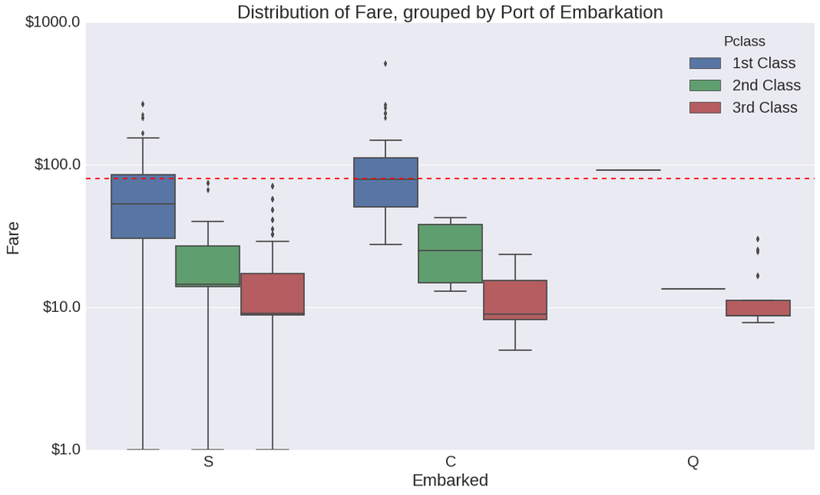

```python
## Clean up missing variables


## Embarked - Looking at the distribution of these passenger fares with respect to passenger
## class and port of embarkation, there is a strong case to be made for 'C' (Charbourg) being
## the missing value of our first class passengers. The median cost of a 1st class passengers
## ticket from Charbourg is around $80 - exactly the price our missing values.

df = full[(full.Embarked.notnull()) & (full.df == 'Train')]
sns.set(style = 'whitegrid')
sns.set(font_scale=2)
fig, ax = plt.subplots(figsize = (17,10))
g = sns.categorical.boxplot('Embarked', df.Fare + 1,'Pclass', data = df, ax= ax)
g.set_yscale('log')
g.set_ylim(top = 1000)
g.set_yticklabels(['${:.1f}'.format(y) for y in g.get_yticks()])
g.axhline(y=80, ls = '--', color = 'r')
g.set_title('Distribution of Fare, grouped by Port of Embarkation');

full.Embarked = np.where(~full.Embarked.notnull(),'C',full.Embarked)
```

Looking at the distribution of passenger fares with respect to passenger class and port of embarkation for the training data, there is a strong case to be made for 'C' (Charbourg) being the missing value of our first class passengers. The median cost of a 1st class passengers ticket from Charbourg is around $80 - exactly the price of our missing values.

## Cabin - Missing value imputation

Next up cabin, with approximately 1000 missing values out of 1300 there are far too many to impute with any real conviction. Coupled with this, a high percentage of the values we do have are unique and generally speaking this isn't good for prediction.

*Cabin variable description*:

```python
full.Cabin.describe()
```

```
count             295
unique            186
top       C23 C25 C27
freq                6
Name: Cabin, dtype: object
```

On the other hand, the names of the levels for the cabin variable seem to have a regular structure: each starts with a capital letter followed by a number. By grouping cabin just by this letter, we can reduce the number of levels while potentially extracting useful information. This new variable will be called 'Deck' and missing values will be encoded as 'U' for unknown.

## Fare - Missing value imputation

Just the one missing value for Fare, a 60 year old gentleman travelling in third class who embarked from Southampton.

```python
## Fare - 1 missing value.

full[full.Fare.isnull()]
```

|  | Age | Cabin | Embarked | Fare | Name | Parch | PassengerId | Pclass | Sex | SibSp | Survived | Ticket | df | Deck |
| --- | --- | --- | --- | --- | --- | --- | --- | --- | --- | --- | --- | --- | --- | --- |
| 1043 | 60.5 | NaN | S | NaN | Storey, Mr. Thomas | 0 | 1044 | 3rd Class | male | 0 | NaN | 3701 | Test | U |

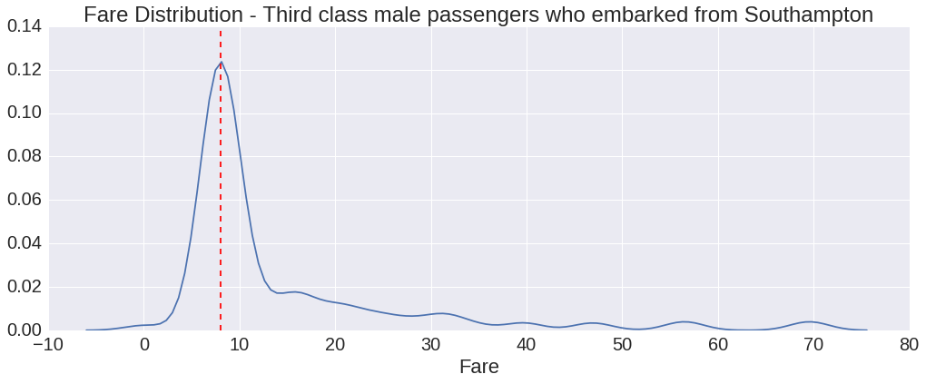

```python
## Third class, Male, embarked from S. Let's take a look at the distribution

fig, ax = plt.subplots(figsize = (17,6))
df_3rd_S = full[(full.Pclass == '3rd Class') & (full.Embarked == 'S')
                   & (full.Fare.notnull()) & (full.df == 'Train')]
sns.distplot(df_3rd_S.Fare.dropna(), axlabel= 'Fare' ,hist = False, ax = ax)
plt.axvline(x = df_3rd_S.Fare.median(), ls = '--', color = 'r')
plt.title('Fare Distribution - Third class male passengers who embarked from Southampton');
```

## Age - Missing value imputation

As we noted earlier, there are quite a few missing **Age** values in our data, over 260 infact. This means we need to be be a bit cleverer with our imputation. To do this, we will introduce a new variable **Title** consisting of salutations parsed from the **Name** variable; this will help in both imputation and be an interesting variable for survival prediction.

*Title counts:*

```python
## Age - First we are going to create new variable Title which will both help in imputing
## age and an interesting variable for survival prediction.

salutations = full.Name.str.extract(r'\s(\w*)\.', flags= re.IGNORECASE)
salutations.value_counts()
```

```
Mr          757
Miss        260
Mrs         197
Master       61
Dr            8
Rev           8
Col           4
Ms            2
Mlle          2
Major         2
Lady          1
Sir           1
Dona          1
Capt          1
Don           1
Jonkheer      1
Mme           1
Countess      1
Name: Name, dtype: int64
```

Now if we group passengers by **Title** and **Pclass** and calculate the median of the resultant grouped **Age** distribution, we can contruct sensible values from which to impute our missing values.

*Median age statistics by Title and Pclass:*

```python
full.groupby(['Title', 'Pclass'])['Age'].median().unstack(fill_value= '~')
```

| Pclass Title | 1st Class | 2nd Class | 3rd Class |
| --- | --- | --- | --- |
| Dr | 49 | 38.5 | ~ |
| Lady | 39 | ~ | ~ |
| Master | 6 | 2 | 6 |
| Miss | 30 | 20 | 18 |
| Mr | 41.5 | 30 | 26 |
| Mrs | 45 | 30.5 | 31 |
| Officer | 53 | ~ | ~ |
| Rev | ~ | 41.5 | ~ |
| Sir | 40 | ~ | ~ |

# Feature Engineering

Feature engineering is the process of using domain knowledge of the data to create features that make machine learning algorithms work. Feature engineering is fundamental to the application of machine learning, and is both difficult, time-consuming and requires expert knowledge.

- A feature is a piece of information that might be useful for prediction. Any attribute could be a feature, as long as it is useful to the model.
- The quality and quantity of the features will have great influence on whether the model is good or not, so choosing the right features is very important.
- Better features can produce simpler and more flexible models, and they often yield better results.

Joy of supervised machine learning is that it is an iterative process, we can create and test many new features and discard if not needed. In this particular case, we engineer nine new features.

- Family Size - Number of family members aboard ship
- Person Type - Child if 14 or under, male adult or female adult
- Family Group - Surname
- Ticket Type - Individual, family, friends or family/friends (based on ticket info)
- Passengers on Ticket - Number of passengers travelling on ticket
- Singleton - True if travelling on individual ticket and no family aboard
- *Deceased Child in Group* - True if we know that a child in group (Surname or Ticket) died, false if not
- *Deceased Female in Group* - True if we know that a female in group (Surname or Ticket) died, false if not
- *Surviving Male in Group* - True if we know that a male in group (Surname or Ticket) survived, false if not

# Prediction

Our new engineered features have been created and our missing values have been imputed across both the train and test datasets. We are now ready to build our prediction model.

As mentioned previously, the sklearn package which we will be using only accepts numerical data, so we need to transform some of our variables so that they are suitably encoded. To do this we perform one-hot encoding across all our categorical variables.

*One-Hot Encoding - Pclass example:*

```python
one_hot = df[['PassengerId', 'Name','Pclass | 2nd Class', 'Pclass | 3rd Class' ]][1282:1285]
one_hot.set_index('PassengerId')
```

| PassengerId | Name | Pclass \| 2nd Class | Pclass \| 3rd Class |
| --- | --- | --- | --- |
| 1283 | Lines, Mrs. Ernest H (Elizabeth Lindsey James) | 0 | 0 |
| 1284 | Abbott, Master. Eugene Joseph | 0 | 1 |
| 1285 | Gilbert, Mr. William | 1 | 0 |

## Random Forest Model

Random forests are an ensemble learning method for classification and regression that operate by constructing many decision trees during training. Each tree is constructed from a bootstrapped version of the original training data and a random subset of variables are selected for splitting at each node. These trees are then bagged together and the final prediction is a function of each individual tree's output (commonly the mode for classification).

By averaging multiple decision trees, trained on different parts of the same training set, the goal is to overcome the over-fitting (high variance) problem of an individual decision tree. In practice this comes at the expense of a small increase in the bias and some loss of interpretability, but generally greatly boosts the performance of the final model.

As well as being a strong out-of-the-box classification solution, random forests allow us to compute the relative importance of each attribute, useful for feature selection in future models.

## Results

We constructed a random forest classifier using 2000 trees, tuning the min_samples_leaf parameter with a cross validated grid search to find the optimal parameter settings.

## Feature Importance

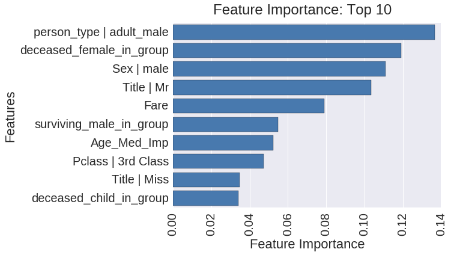

```python
sns.set(font_scale=2)
fig, ax = plt.subplots()
sns.barplot(y = 'feature', x = 'importance', data = features[:10], ax = ax, color=sns.xkcd_rgb["windows blue"])
for label in ax.get_xticklabels():
    label.set_rotation(90)
fig.suptitle("Feature Importance: Top 10")
plt.xlabel('Feature Importance')
plt.ylabel('Features');
```